# Lab 4

Author

Dana Gonzalez

## PM 566 Lab 4

### Step 1: Read in the Data

```r
if (!file.exists("met_all.gz"))
  download.file(
    url = "https://raw.githubusercontent.com/USCbiostats/data-science-data/master/02_met/met_all.gz",
    destfile = "met_all.gz",
    method   = "libcurl",
    timeout  = 60
    )
met <- data.table::fread("met_all.gz")
```

### Step 2: Prepare the Data

#### Remove temperatures less than -17C.

#### Remove missing data coded as 9999, 999, etc.

```r
met <- met[met$temp > -17, ]
met$elev[met$elev == 9999.0] <-NA
```

```r
met$Date <- as.Date(paste(met$year, met$month, met$day, sep = "-"))
library(lubridate)
met$Week <- week(met$Date)
met <- met [met$Week == 31,]
```

#### Compute the mean by station of the variables temp, rh, wind.sp, vis.dist, dew.point, lat, lon, ande elev.

```r
library(dplyr)
met_avg <- summarize(met,
                      temp = mean(temp),
                      rh = mean(rh),
                      wind.sp = mean(wind.sp),
                      vis.dist = mean(vis.dist),
                      dew.point = mean(dew.point),
                      lat = mean(lat),
                      lon = mean(lon),
                      elev = mean(elev),
                      .by = c(USAFID))
```

#### Create a region variable for NW, SW, NE, and SE based on lon = -98.00 and lat = 39.71 degrees.

```r
met$region <- ifelse(met$lon < -98.00 & met$lat > 39.71, "NW",
                ifelse(met$lon < -98.00 & met$lat <= 39.71, "SW",
                ifelse(met$lon >= -98.00 & met$lat > 39.71, "NE",
                ifelse(met$lon >= -98.00 & met$lat <= 39.71, "SE",
                NA))))
```

#### Create a categorical variable for elevation.

```r
met$elev_cat <- ifelse(met$elev > 252, "high", "low")
```

### Step 3

#### Examine windspeed by region.

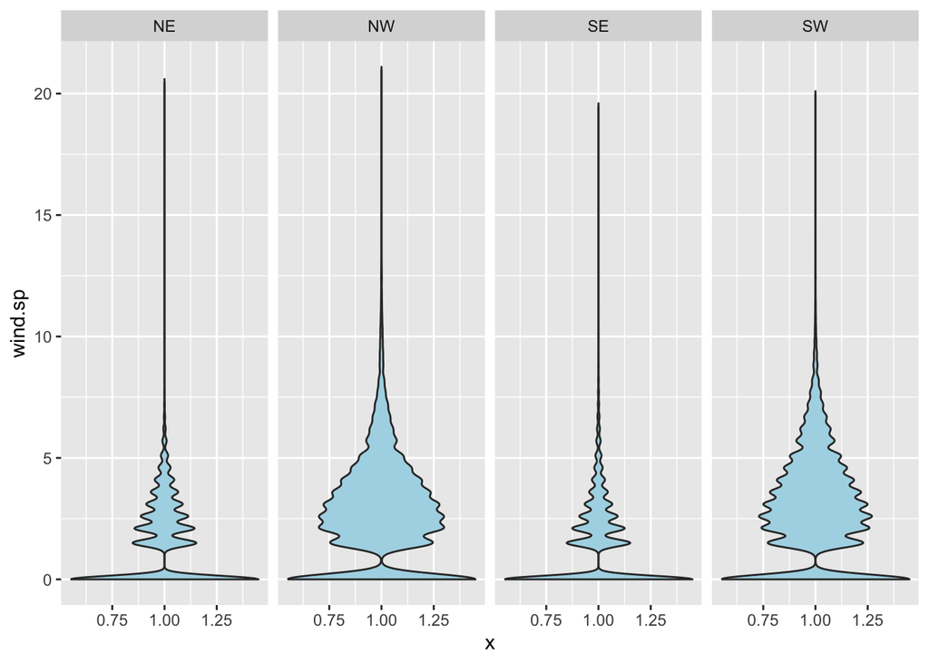

```r
library(tidyverse)
met <- met[!is.na(met$wind.sp),]
ggplot(met, aes(x = 1, y = wind.sp)) +
  geom_violin(fill = "lightblue") +
  facet_wrap(~region, nrow = 1)
```

```r
labs(title = "Windspeed by Region",
     x = "Region",
     y = "Windspeed")
```

```
$x
[1] "Region"

$y
[1] "Windspeed"

$title
[1] "Windspeed by Region"

attr(,"class")
[1] "labels"
```

```r
theme = "minimal"
met <- met %>%
  filter(!is.na(wind.sp))
```

The Northeast and Southeast regions seem to have less variable windspeeds than the Northwest and Southwest regions. This can be seen by the height of the “violins” showing a greater range of windspeeds (observations across a greater range of windspeed values).

#### Examine dewpoint by region.

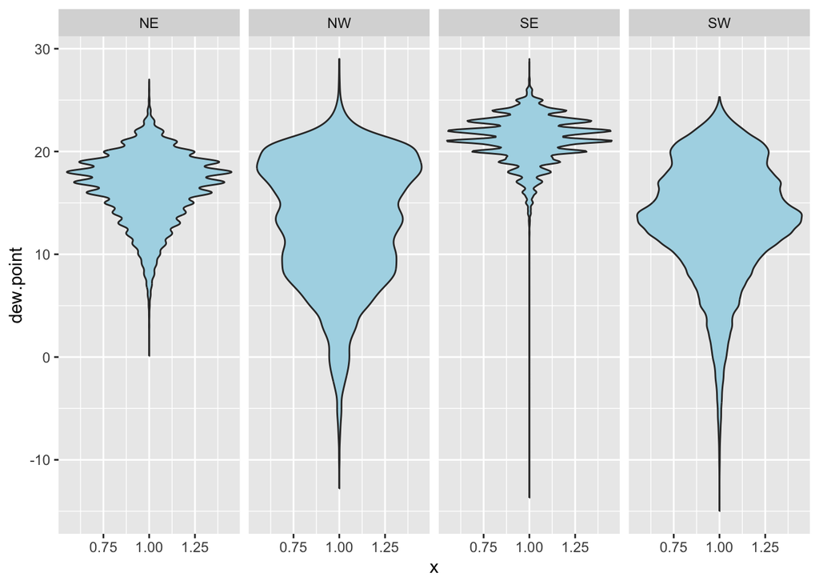

```r
met <- met[!is.na(met$dew.point),]
ggplot(met, aes(x = 1, y = dew.point)) +
  geom_violin(fill = "lightblue") +
  facet_wrap(~region, nrow = 1)
```

```r
labs(title = "Dewpoint by Region",
     x = "Region",
     y = "Dewpoint")
```

```
$x
[1] "Region"

$y
[1] "Dewpoint"

$title
[1] "Dewpoint by Region"

attr(,"class")
[1] "labels"
```

```r
theme = "minimal"
met <- met %>%
  filter(!is.na(dew.point))
```

The Southeast region seems to have the greatest values for the dewpoint variable (height of the “violins”), whereas the Northwest and Southwest regions seem to have a greater number of observations per dewpoint value (width of the “violins”).

### Step 4

#### Examine the association between dew point and wind speed by region.

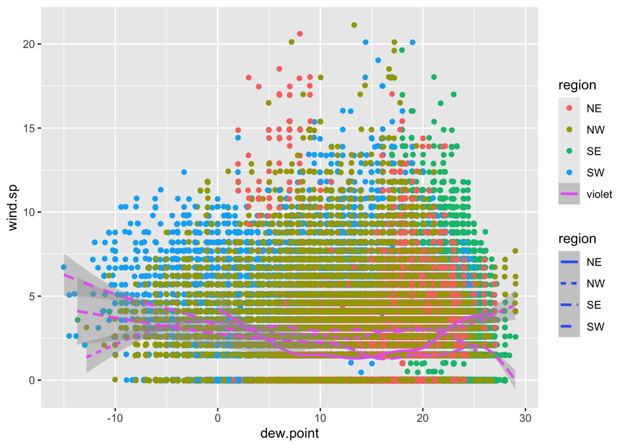

```r
met <- met[!is.na(met$region),]
ggplot(data = met) +
  geom_jitter(mapping = aes(x = dew.point, y = wind.sp, color = region )) +
  geom_smooth(mapping = aes(x = dew.point, y = wind.sp, linetype = region, col = "violet"))
```

None of the associations, for any region, show a distinct linear relationship. However, can see that some regions are shifted towards a particular direction on the x-axis. For instance, the data for the SW region is shifted towards the left (negative values), whereas the Northeast and Southeast regions are shifted towards the right (positive values). The data for the Northwest region encompasses the majority of the range (for the data).

### Step 5

##### Create barplots of the weather stations by elevation category colored by region.

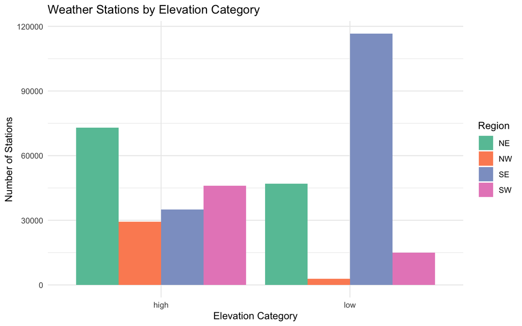

```r
met <- met[!is.na(met$region),]
met <- met[!is.na(met$elev_cat),]
ggplot(met, aes(x = met$elev_cat, fill = met$region)) +
  geom_bar(position = "dodge") +  scale_fill_brewer(palette = "Set2") +
  labs(title = "Weather Stations by Elevation Category",
       x = "Elevation Category",
       y = "Number of Stations",
       fill = "Region") +
  theme_minimal()
```

Of the four regions, the Northwest region has the least amount of weather stations, across both elevation categories. The Northeast, on the other hand, has the greatest amount of stations in high elevations, and the Southeast has the greatest amount of stations in low elevations. Too, the difference in low elevation stations between the Northwest and Southeast is particularly stark: the Northwest has less than 7,500 (at least), whereas the Southeast has nearly 120,000.

### Step 6

#### Examine mean dew point and wind speed by region with standard deviation error bars.

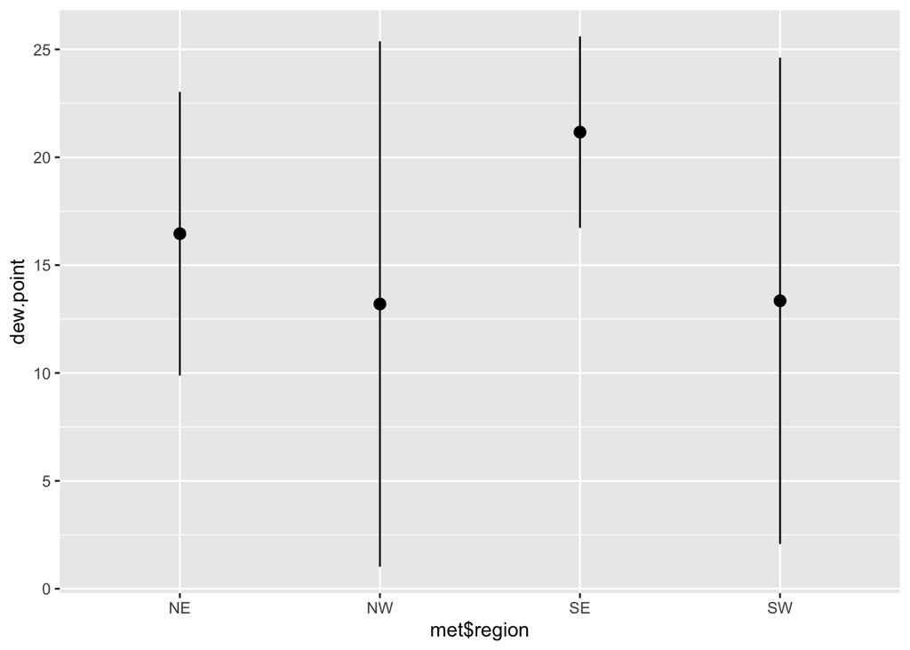

```r
met <- met[!is.na(met$region),]
met <- met[!is.na(met$dew.point),]
met <- met[!is.na(met$wind.sp),]
l <- met[!is.na(met$region), ] |>
  ggplot() +
  stat_summary(mapping = aes(x = met$region, y = dew.point),
               fun.min = min,
               fun.max = max,
               fun = median,
               fun.data = mean_sdl)
l
```

```r
labs(title = "Mean Dew Point by Region with Standard Deviation Error Bars",
       x = "Region",
       y = "Mean Dew Point") +
  theme_minimal()
```

```r
  summarize(met,
            dew.point = mean(dew.point))
```

```
  dew.point
1  17.60866
```

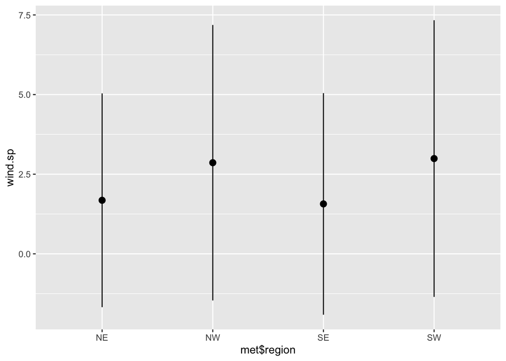

```r
met <- met[!is.na(met$region),]
met <- met[!is.na(met$dew.point),]
met <- met[!is.na(met$wind.sp),]
l <- met[!is.na(met$region), ] |>
  ggplot() +
  stat_summary(mapping = aes(x = met$region, y = wind.sp),
               fun.min = min,
               fun.max = max,
               fun = median,
               fun.data = mean_sdl)
l
```

```r
labs(title = "Mean Wind Speed by Region with Standard Deviation Error Bars",
       x = "Region",
       y = "Mean Wind Speed") +
  theme_minimal()
```

```r
  summarize(met,
            wind.sp = mean(wind.sp))
```

```
   wind.sp
1 1.956558
```

### Step 7

#### Make a map showing the spatial trend in relative humidity in the US.

```r
met <- met[!is.na(met$rh),]
library(leaflet)
met_avg2 <- met[,.(rh = mean(rh,na.rm=TRUE), lat = mean(lat), lon = mean(lon)),  by=c("USAFID")]
met_avg2 <- met_avg2[!is.na(rh)]
rh.pal <- colorNumeric(c('lightblue','goldenrod'), domain = met_avg2$rh)
rh.pal
```

[output not shown]

```r
leaflet(met_avg2) |>
  addProviderTiles('CartoDB.Positron') |>
  addCircles(lat = ~lat, lng = ~lon,
             opacity = 1, fillOpacity = 1, radius = 400, color = ~ rh.pal(rh))
```

[interactive chart not shown]

Looking at the generated maps of the United States, the areas with the lowest relative humidity (rh) values seem to be concentrated in the Mountain states, such as Nevada, Idaho, Utah, Arizona, as well as the easternmost regions of California and the westernmost parts of Texas. However, we must notes that there are relatively few observations in this region when compared to areas with high rh values, such as the South and the East Coast.

### Step 8

#### Use a ggplot extension.

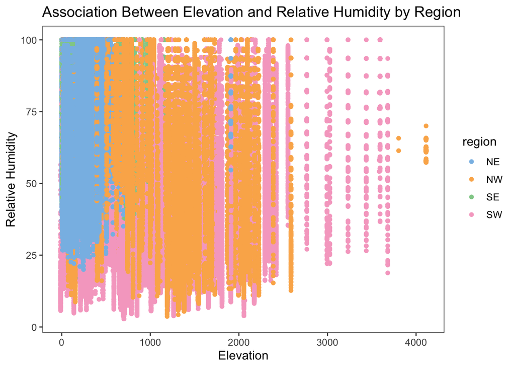

```r
library(ggplot2)
library(dplyr)
library(tidyverse)
library(ggthemes)
ggplot(data = met) +
  geom_point(mapping = aes(x = elev, y = rh, color = region)) +
  theme_few() +
  scale_colour_few('Light') +
  labs(title = "Association Between Elevation and Relative Humidity by Region",
       x = "Elevation",
       y = "Relative Humidity",
       fill = "Region")
```